# Tutorial for Bioregionalization R package

Pierre Denelle

2020-01-30

The principle of the package is illustrated by the following figure.

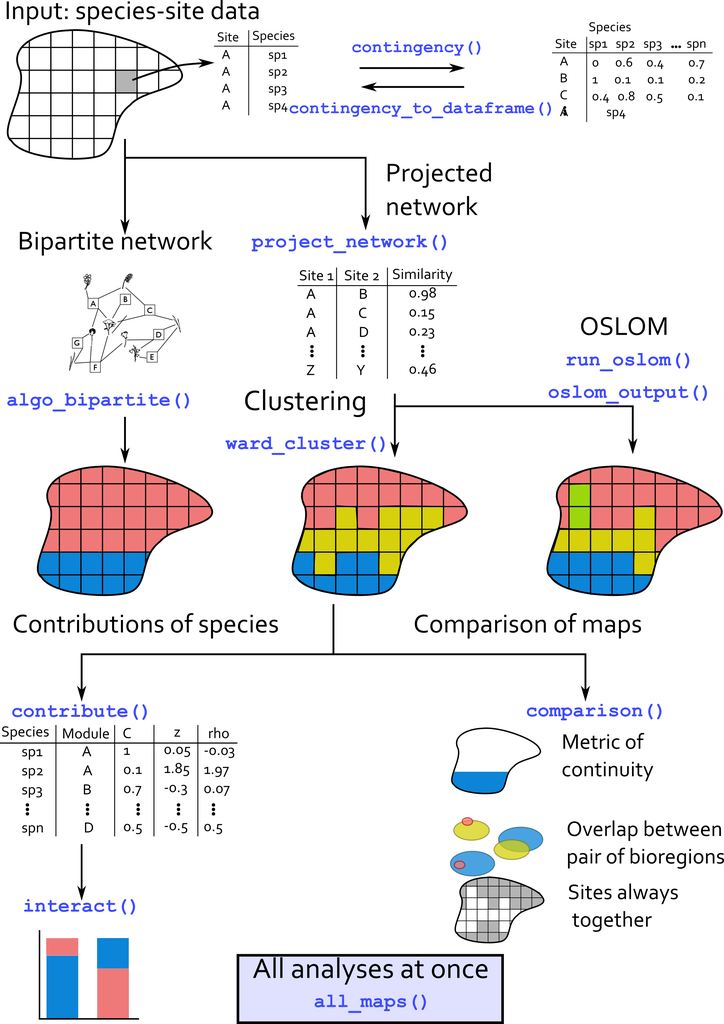

```r
knitr::include_graphics("../figures/Bioregionalization_scheme3.png")
```

# 1 Virtual dataset

For every species in every cell, we could derive a suitability index. Species with suitability index inferior to 0.15 were arbitrarily set absent.

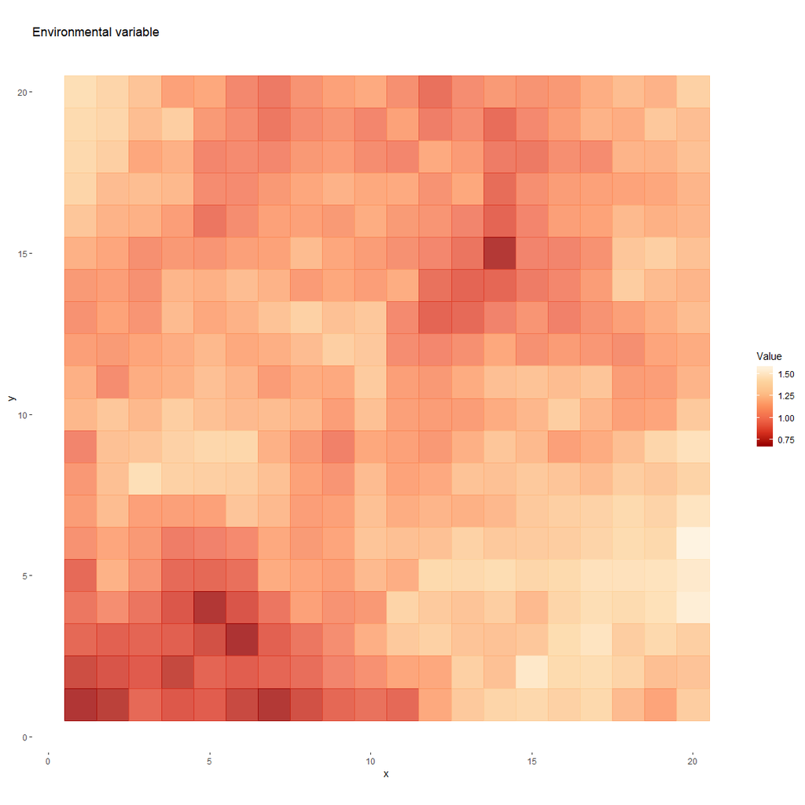

```r
# Import virtual dataset
data("virtual_sp")

# Only species data.frame
sp_df <- virtual[[1]]

# Plot of environmental values
sp_df %>%
  distinct(site, .keep_all = TRUE) %>%
  ggplot(aes(x, y)) +
  geom_tile(aes(fill = env, color = env),
            alpha = 0.8, width = 1, height = 1) +
  scale_color_distiller("Value", palette = "OrRd") +
  scale_fill_distiller("Value", palette = "OrRd") +
  coord_equal() +
  labs(title = "Environmental variable") +
  theme(panel.background = element_rect(fill = "transparent",colour = NA))
```

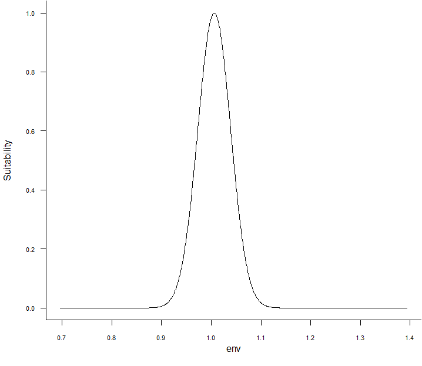

```r
knitr::include_graphics("../figures/sp50_response_curve.png")
```

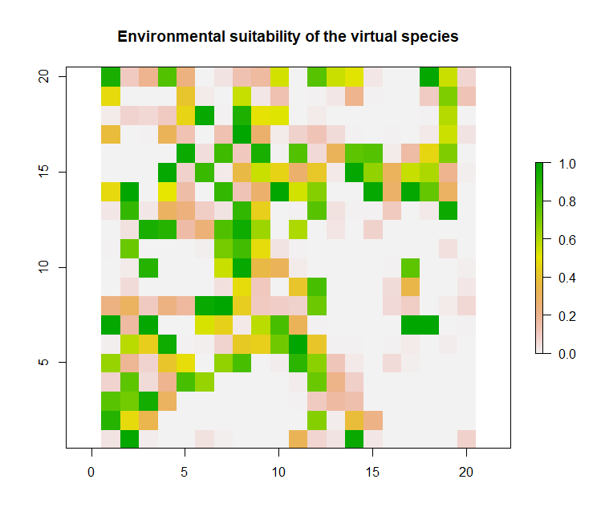

```r
knitr::include_graphics("../figures/sp50_suitability.png")
```

The first step is to convert the data.frame into a contingency table.

```r
sp_mat <- contingency(sp_df[which(sp_df$pa != 0), ],
                      "site", "sp", ab = NULL, binary = TRUE)
knitr::kable(sp_mat[1:5, 1:5])
```

|  | sp1 | sp2 | sp3 | sp4 | sp5 |
| --- | --- | --- | --- | --- | --- |
| site1 | 1 | 1 | 1 | 1 | 1 |
| site10 | 0 | 0 | 0 | 0 | 0 |
| site100 | 0 | 0 | 0 | 0 | 0 |
| site101 | 0 | 0 | 0 | 0 | 0 |
| site102 | 0 | 0 | 0 | 0 | 0 |

```r
# With weights
sp_mat_w <- contingency(sp_df, "site", "sp", ab = "suitab", binary = FALSE)
knitr::kable(sp_mat_w[1:5, 1:5])
```

|  | sp1 | sp2 | sp3 | sp4 | sp5 |
| --- | --- | --- | --- | --- | --- |
| site1 | 0.9158657 | 0.9312874 | 0.9428647 | 0.9517664 | 0.9587522 |
| site10 | 0.0000000 | 0.0000000 | 0.0000000 | 0.0000000 | 0.0000000 |
| site100 | 0.0000000 | 0.0000000 | 0.0000000 | 0.0000000 | 0.0000000 |
| site101 | 0.0000000 | 0.0000000 | 0.0000000 | 0.0000000 | 0.0000000 |
| site102 | 0.0000000 | 0.0000000 | 0.0000000 | 0.0000000 | 0.0000000 |

# 2 Community detection on projected networks

## 2.1 Projection of the network

We then need to project the network.

```r
sp_proj <- project_network(sp_mat, similarity = "simpson")
sp_proj <- sp_proj[, c("id1", "id2", "simpson")]

knitr::kable(head(sp_proj))
```

| id1 | id2 | simpson |
| --- | --- | --- |
| 4 | 6 | 1.0000000 |
| 7 | 8 | 1.0000000 |
| 7 | 9 | 0.8571429 |
| 8 | 9 | 1.0000000 |
| 5 | 10 | 0.6666667 |
| 4 | 11 | 1.0000000 |

```r
sp_proj_w <- project_network(sp_mat_w, similarity = "bray")
sp_proj_w <- sp_proj_w[, c("id1", "id2", "bray")]

knitr::kable(head(sp_proj_w))
```

|  | id1 | id2 | bray |
| --- | --- | --- | --- |
| 2 | 2 | 1 | 0.0162964 |
| 3 | 3 | 1 | 0.0000000 |
| 4 | 4 | 1 | 0.0005101 |
| 5 | 5 | 1 | 0.0000020 |
| 6 | 6 | 1 | 0.0002640 |
| 7 | 7 | 1 | 0.0016733 |

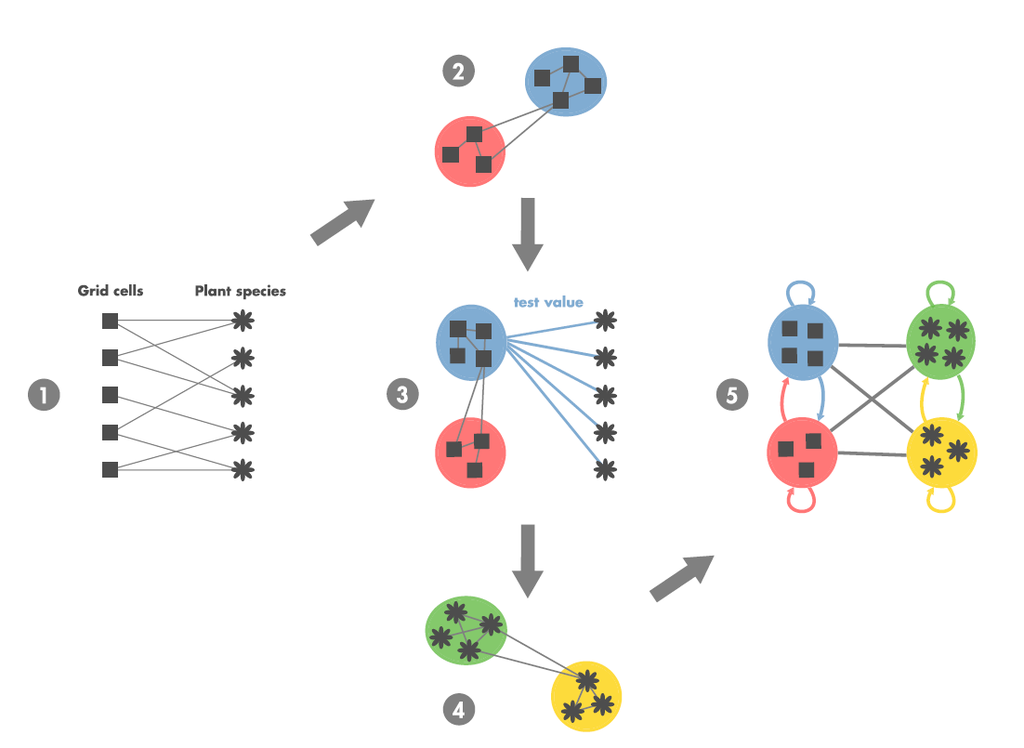

```r
knitr::include_graphics("../figures/Lenormand_et_al_2019_Figure2.png")
```

# 3 Community detection: Order Statistics Local Optimization Method

Running OSLOM. tp files containing the modularity results are directly stored within the virtual dataset, but the following chunk can be run independently.

Output of OSLOM are stored in a chosen directory and can be import into R with the command `readRDS()`.

```r
run_oslom(sp_proj, n_runs = 5, t_param = 0.1, cp_param = 0.5,
          saving_directory = "D:/PIERRE_DENELLE/CarHab/Bioregionalization_extra/")

res <- readRDS("D:/PIERRE_DENELLE/CarHab/Bioregionalization_extra/tp.rds")
file.rename("D:/PIERRE_DENELLE/CarHab/Bioregionalization_extra/tp.rds",
            "D:/PIERRE_DENELLE/CarHab/Bioregionalization_extra/tp_binary.rds")
# With weights
run_oslom(sp_proj_w, n_runs = 5, t_param = 0.1, cp_param = 0.5,
          saving_directory = "D:/PIERRE_DENELLE/CarHab/Bioregionalization_extra/")

res_w <- readRDS("D:/PIERRE_DENELLE/CarHab/Bioregionalization_extra/tp.rds")
```

Converting the OSLOM .tp file into a list.

```r
# Format OSLOM output into a data.frame
oslom_vignette <- oslom_output(virtual[[2]], sp_mat)
# With weights
oslom_vignette_w <- oslom_output(virtual[[3]], sp_mat_w)

print(paste0("Number of bioregions detected = ",
             length(unique(oslom_vignette$bioregion)),
             "; and with weights: ",
             length(unique(oslom_vignette_w$bioregion))))
```

```
## [1] "Number of bioregions detected = 9; and with weights: 6"
```

## 3.1 Species’ contributions

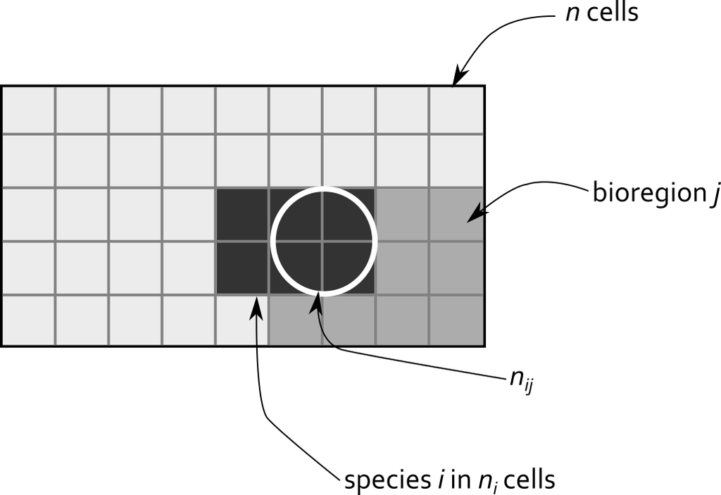

```r
knitr::include_graphics("../figures/zscore_scheme.png")
```

$$\rho_{ij} = \frac{n_{ij} - \frac{n_in_j}{n}}{\sqrt(\frac{n-n_j}{n-1}(1-\frac{n_j}{n})\frac{n_jn_i}{n})}$$

The interactions between the different bioregions can then be calculated following these equations:

$$\hat\rho_{ij}^{+} = {\rho_{ij}}_{\rho_{ij}>1.96}$$
We normalize the rows:

$$\hat\rho_{ij}^{+} = \frac{\rho_{ij}^{+}}{\sum_i\rho_{ij}^{+}}$$

Finally, we determine for each bioregion how each set of species contributes to it.

$$\lambda_{jj'} = \frac{1}{|A_j|}\sum_{i \in A_{j}}\hat\rho_{jj'}^{+}$$

```r
# 10 sites with species richness belonging to [1, 3]
set.seed(1)
sites <- sapply(paste0("site", seq(1:10)),
                function(x) rep(x, sample(c(1:3), 1)))
# Pool of 5 species distributed across the sites
species <- lapply(sites,
                  function(x) sample(paste0("sp", seq(1:5)),
                                     length(x), replace = TRUE))
# 3 bioregions assigned randomly
bioregions <- sample(paste0("bio", seq(1:3)), length(sites), replace = TRUE)
bioregions <- data.frame(site = names(sites),
                         bioregion = bioregions)

# Conversion to data frame
fuzzy <- data.frame(site = as.character(unlist(sites)),
                    sp = as.character(unlist(species)))
fuzzy <- left_join(fuzzy, bioregions, by = "site")

table(fuzzy$sp, fuzzy$bioregion)
```

```
##
##       bio1 bio2 bio3
##   sp1    2    2    2
##   sp2    1    2    2
##   sp3    0    1    1
##   sp4    1    0    1
##   sp5    1    4    1
```

```r
# Compute zscores
zscores <- zscore(fuzzy, sp_col = "sp", site_col = "site",
                  bioregion_col = "bioregion", output_format = "matrix")
zscores
```

```
##      bioregion
## sp          bio1       bio2       bio3
##   sp1  0.2020305 -0.4082483  0.2020305
##   sp2 -0.5532833  0.0000000  0.5532833
##   sp3 -1.0497813  0.3535534  0.6998542
##   sp4  0.6998542 -1.4142136  0.6998542
##   sp5 -0.8081220  1.6329932 -0.8081220
```

```
## $lambda
##          bio1     bio2     bio3
## bio1 75.00000  0.00000 25.00000
## bio2  0.00000 66.78141 33.21859
## bio3 16.66667 11.18761 72.14572
##
## [[2]]
```

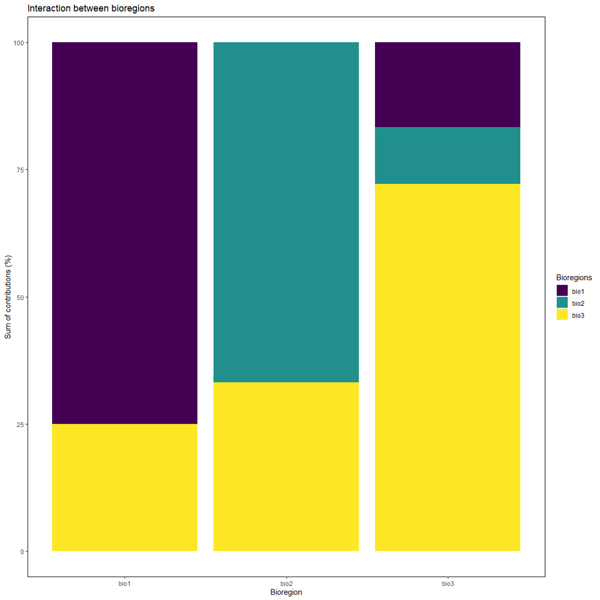

```r
# Interactions between bioregions
interact(input_network = "projected",
         dat = zscores, plot = TRUE, output_format = "matrix")
```

```r
# tmp <- left_join(sp_df, oslom_vignette, by = "site")
tmp <- left_join(sp_df[which(sp_df$pa > 0), ], oslom_vignette, by = "site")
# table(tmp$sp, tmp$bioregion)

z_scores <- zscore(tmp, sp_col = "sp", site_col = "site",
                   bioregion_col = "bioregion", output_format = "dataframe")

top10 <- z_scores %>%
  group_by(bioregion) %>%
  top_n(n = 10, zscore) %>% # extract top 10
  mutate(rank = rank(-zscore, # ranking zcore in an ascending order
                     ties.method = "first")) %>% # if tie zscore, first species
  dplyr::select(sp, bioregion, zscore, rank) %>%
  mutate(zscore = round(zscore, 1)) %>% # rounding zscore to 1 digit
  as.data.frame()

knitr::kable(top10[which(top10$bioregion == "2"), ])
```

|  | sp | bioregion | zscore | rank |
| --- | --- | --- | --- | --- |
| 11 | sp51 | 2 | 13.5 | 10 |
| 12 | sp52 | 2 | 13.8 | 9 |
| 13 | sp53 | 2 | 15.2 | 8 |
| 14 | sp54 | 2 | 15.5 | 7 |
| 15 | sp55 | 2 | 16.3 | 6 |
| 16 | sp56 | 2 | 16.5 | 5 |
| 17 | sp57 | 2 | 17.1 | 4 |
| 18 | sp58 | 2 | 17.2 | 3 |
| 19 | sp59 | 2 | 18.8 | 1 |
| 20 | sp60 | 2 | 18.7 | 2 |

## 3.2 Interaction between bioregions

```r
z_scores <- zscore(tmp, sp_col = "sp", site_col = "site",
                   bioregion_col = "bioregion", output_format = "matrix")

lambda <- interact(input_network = "projected",
                   dat = z_scores, plot = TRUE, output_format = "matrix")
knitr::kable(head(lambda[[1]]))
```

| 1 | 2 | 3 | 4 | 5 | 6 | 7 | 8 | 9 |
| --- | --- | --- | --- | --- | --- | --- | --- | --- |
| 100 | 0 | 0.00000 | 0 | 0 | 0 | 0.0000000 | 0 | 0 |
| 0 | 100 | 0.00000 | 0 | 0 | 0 | 0.0000000 | 0 | 0 |
| 0 | 0 | 99.72334 | 0 | 0 | 0 | 0.2766644 | 0 | 0 |
| 0 | 0 | 0.00000 | 100 | 0 | 0 | 0.0000000 | 0 | 0 |
| 0 | 0 | 0.00000 | 0 | 100 | 0 | 0.0000000 | 0 | 0 |
| 0 | 0 | 0.00000 | 0 | 0 | 100 | 0.0000000 | 0 | 0 |

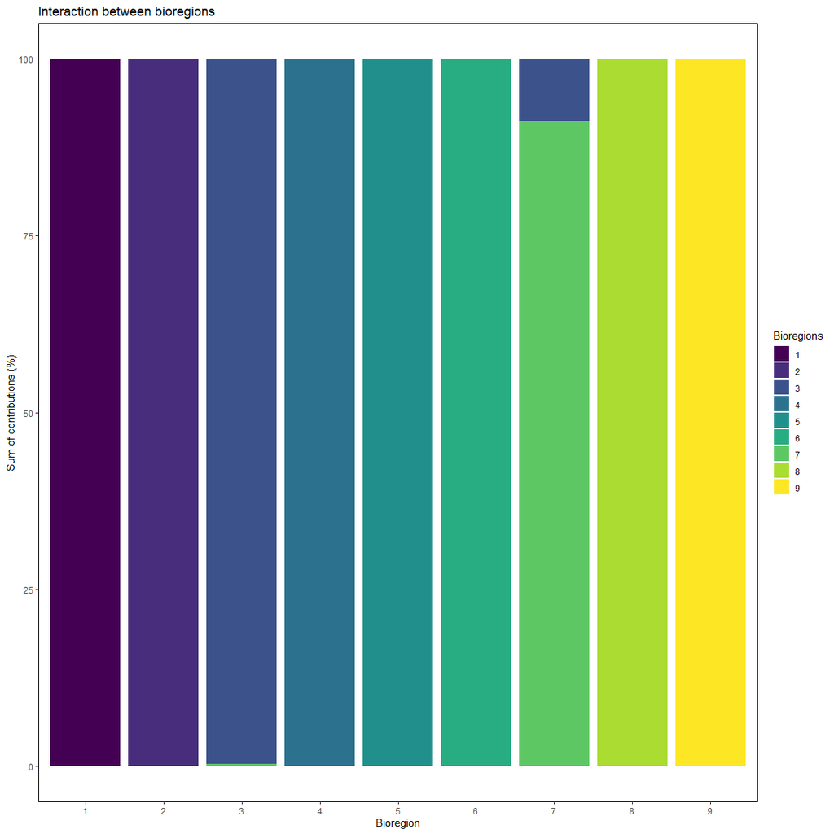

```r
# Plot
lambda[[2]]
```

# 4 Clustering

Example with Ward analysis and k-means clustering.

```r
# CA_res <- CA_cluster(sp_mat)
ward_res <- ward_cluster(sp_mat, K.max = 6)
```

# 5 Community detection on bipartite networks

## 5.1 Several algorithms

Bipartite algorithms applied on example dataset.

```r
# With fastgreedy
bip <- algo_bipartite(dat = sp_mat, algo = "greedy", weight = FALSE)

# With Beckett algorithm
bip2 <- algo_bipartite(dat = sp_mat, algo = "LPAwb", weight = FALSE)

# With Infomap
bip_infomap <- algo_bipartite(dat = sp_mat, algo = "infomap", weight = FALSE)

# Only sites
bip_site <- bip %>%
  filter(cat == "site") %>%
  rename(site = node) %>%
  dplyr::select(site, module)

bip_site2 <- bip2 %>%
  filter(cat == "site") %>%
  rename(site = node) %>%
  dplyr::select(site, module)

bip_site_infomap <- bip_infomap %>%
  filter(cat == "site") %>%
  rename(site = node) %>%
  dplyr::select(site, module)
```

## 5.2 Species and sites’ contributions

Cz computation on bipartite results.

```r
bip_cz <- bip[, c("node", "module", "cat")]
colnames(bip_cz) <- c("node", "mod", "cat")

cz_bip <- cz(dat = sp_df[which(sp_df$pa > 0), ], sp_col = "sp",
             site_col = "site", bip = bip_cz, ab = NULL)

head(cz_bip[[1]])
```

```
##      node mod  cat C n_link_mod mean_link_mod sd_link_mod          z
## 1 site101   1 site 0          6      12.59184    17.51985 -0.3762496
## 2 site103   1 site 0         10      12.59184    17.51985 -0.1479372
## 3 site108   1 site 0         10      12.59184    17.51985 -0.1479372
## 4 site121   1 site 0          9      12.59184    17.51985 -0.2050153
## 5 site123   1 site 0          6      12.59184    17.51985 -0.3762496
## 6 site124   1 site 0          6      12.59184    17.51985 -0.3762496
```

```r
# Interaction
# lambda <- interact(input_network = "bipartite",
#                    dat = link_cz, plot = TRUE, output_format = "matrix")
# knitr::kable(head(lambda[[1]]))
# # Plot
# lambda[[2]]
```

# 6 All contributions

```r
tmp <- left_join(sp_df[which(sp_df$pa > 0), ], oslom_vignette, by = "site")
# table(tmp$sp, tmp$bioregion)

scores <- contribute(dat = tmp, sp_col = "sp", site_col = "site",
                     bioregion_col = "bioregion")
```

Projection on a map.

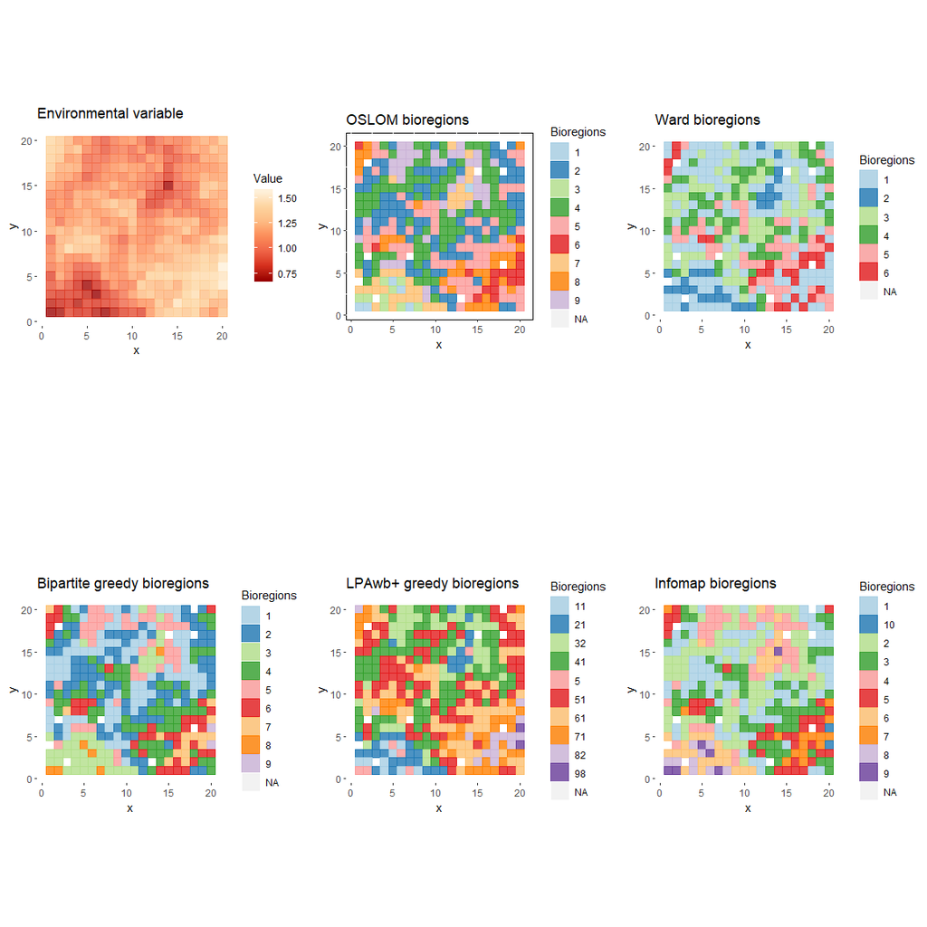

```r
plot_grid(
  # Plot of environmental values
  sp_df %>%
    distinct(site, .keep_all = TRUE) %>%
    ggplot(aes(x, y)) +
    geom_tile(aes(fill = env, color = env),
              alpha = 0.8, width = 1, height = 1) +
    scale_color_distiller("Value", palette = "OrRd") +
    scale_fill_distiller("Value", palette = "OrRd") +
    coord_equal() +
    labs(title = "Environmental variable") +
    theme(panel.background = element_rect(fill = "transparent",colour = NA)),

  # Plot of OSLOM bioregions
  sp_df %>%
    left_join(oslom_vignette, by = "site") %>%
    distinct(site, .keep_all = TRUE) %>%
    ggplot(aes(x, y)) +
    geom_tile(aes(fill = as.factor(bioregion), color = as.factor(bioregion)),
              alpha = 0.8, width = 1, height = 1) +
    scale_color_brewer("Bioregions", palette = "Paired") +
    scale_fill_brewer("Bioregions", palette = "Paired") +
    # scale_color_viridis_d("Bioregions", option = "E") +
    # scale_fill_viridis_d("Bioregions", option = "E") +
    coord_equal() +
    labs(title = "OSLOM bioregions") +
    theme(panel.background = element_rect(fill = "transparent",
                                          colour = "black")),

  # Plot of Ward bioregions
  sp_df %>%
    left_join(ward_res, by = "site") %>%
    distinct(site, .keep_all = TRUE) %>%
    ggplot(aes(x, y)) +
    geom_tile(aes(fill = as.factor(cluster), color = as.factor(cluster)),
              alpha = 0.8, width = 1, height = 1) +
    scale_color_brewer("Bioregions", palette = "Paired") +
    scale_fill_brewer("Bioregions", palette = "Paired") +
    coord_equal() +
    labs(title = "Ward bioregions") +
    theme(panel.background = element_rect(fill = "transparent", colour = NA)),

  # Plot of fastgreedy bioregions
  sp_df %>%
    left_join(bip_site, by = "site") %>%
    distinct(site, .keep_all = TRUE) %>%
    ggplot(aes(x, y)) +
    geom_tile(aes(fill = as.factor(module), color = as.factor(module)),
              alpha = 0.8, width = 1, height = 1) +
    scale_color_brewer("Bioregions", palette = "Paired") +
    scale_fill_brewer("Bioregions", palette = "Paired") +
    coord_equal() +
    labs(title = "Bipartite greedy bioregions") +
    theme(panel.background = element_rect(fill = "transparent", colour = NA)),

  # Plot of LPAwb bioregions
  sp_df %>%
    left_join(bip_site2, by = "site") %>%
    distinct(site, .keep_all = TRUE) %>%
    ggplot(aes(x, y)) +
    geom_tile(aes(fill = as.factor(module), color = as.factor(module)),
              alpha = 0.8, width = 1, height = 1) +
    scale_color_brewer("Bioregions", palette = "Paired") +
    scale_fill_brewer("Bioregions", palette = "Paired") +
    coord_equal() +
    labs(title = "LPAwb+ greedy bioregions") +
    theme(panel.background = element_rect(fill = "transparent", colour = NA)),

  # Plot of Infomap bioregions
  sp_df %>%
    left_join(bip_site_infomap, by = "site") %>%
    distinct(site, .keep_all = TRUE) %>%
    ggplot(aes(x, y)) +
    geom_tile(aes(fill = as.factor(module), color = as.factor(module)),
              alpha = 0.8, width = 1, height = 1) +
    scale_color_brewer("Bioregions", palette = "Paired") +
    scale_fill_brewer("Bioregions", palette = "Paired") +
    coord_equal() +
    labs(title = "Infomap bioregions") +
    theme(panel.background = element_rect(fill = "transparent", colour = NA)),

  nrow = 2)
```

# 7 Comparison of different bioregionalizations

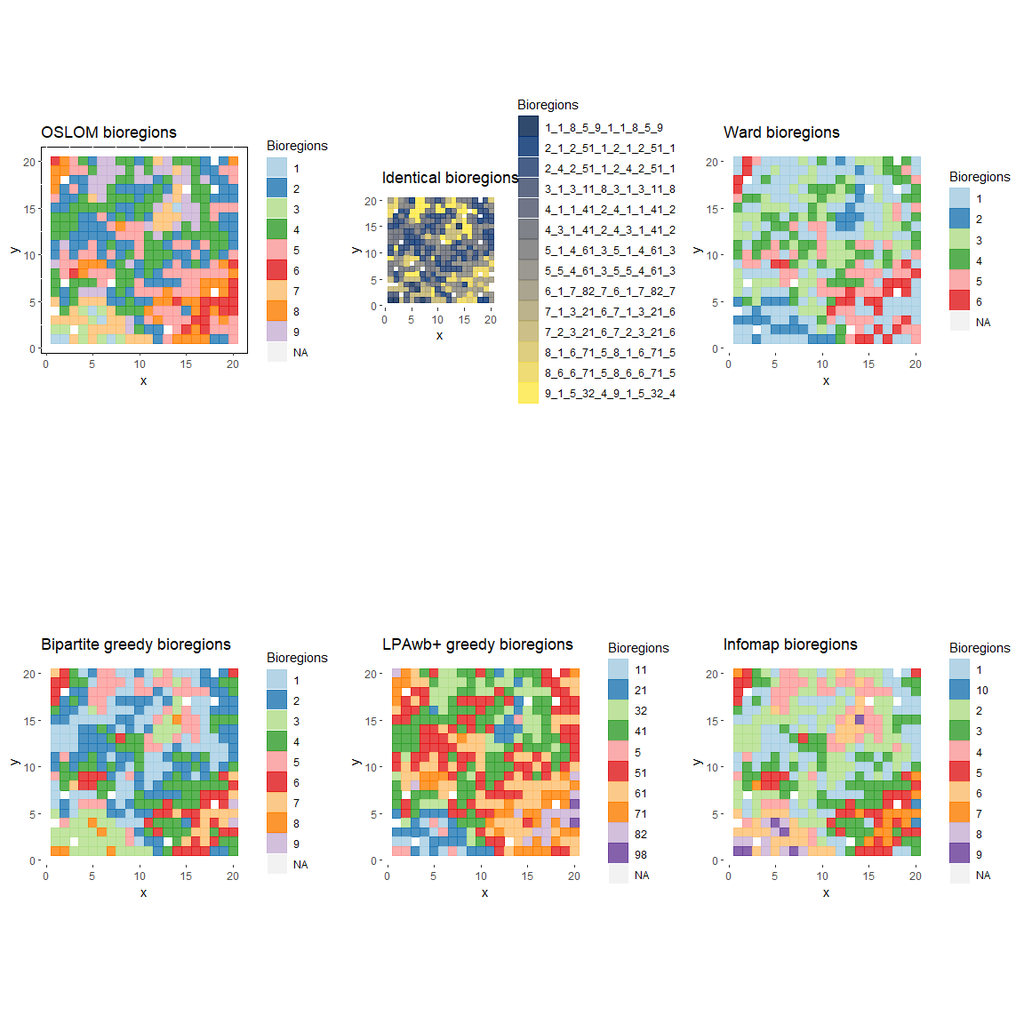

```r
# Gather all the bioregionalizations
all_bioregions <- sp_df %>%
  select(site, x, y, env) %>%
  distinct(site, .keep_all = TRUE) %>%
  left_join(oslom_vignette, by = "site") %>% # add OSLOM
  rename(oslom = bioregion) %>%
  left_join(ward_res, by = "site") %>% # add Ward
  rename(ward = cluster) %>%
  left_join(bip_site, by = "site") %>% # add greedy
  distinct(site, .keep_all = TRUE) %>%
  rename(greedy = module) %>%
  left_join(bip_site2, by = "site") %>% # add LPAwb
  distinct(site, .keep_all = TRUE) %>%
  rename(lpawb = module) %>%
  left_join(bip_site_infomap, by = "site") %>% # add infomap
  distinct(site, .keep_all = TRUE) %>%
  rename(infomap = module)

# Test of comparison function
all100 <- comparison(all_bioregions, bio_col = c(5:9))

# Comparison of maps
plot_grid(
  # Plot of OSLOM bioregions
  sp_df %>%
    left_join(oslom_vignette, by = "site") %>%
    distinct(site, .keep_all = TRUE) %>%
    ggplot(aes(x, y)) +
    geom_tile(aes(fill = as.factor(bioregion), color = as.factor(bioregion)),
              alpha = 0.8, width = 1, height = 1) +
    scale_color_brewer("Bioregions", palette = "Paired") +
    scale_fill_brewer("Bioregions", palette = "Paired") +
    # scale_color_viridis_d("Bioregions", option = "E") +
    # scale_fill_viridis_d("Bioregions", option = "E") +
    coord_equal() +
    labs(title = "OSLOM bioregions") +
    theme(panel.background = element_rect(fill = "transparent",
                                          colour = "black")),

  # Identical pairs of plots
  all100 %>%
    left_join(all_bioregions[, c("site", "x", "y")], by = c("id1" = "site")) %>%
    distinct(id1, .keep_all = TRUE) %>%
    ggplot(aes(x, y)) +
    geom_tile(aes(fill = as.factor(pair_bio), color = as.factor(pair_bio)),
              alpha = 0.8, width = 1, height = 1) +
    scale_color_viridis_d("Bioregions", option = "E") +
    scale_fill_viridis_d("Bioregions", option = "E") +
    # scale_color_brewer("Bioregions", palette = "Paired") +
    # scale_fill_brewer("Bioregions", palette = "Paired") +
    coord_equal() +
    labs(title = "Identical bioregions") +
    theme(panel.background = element_rect(fill = "transparent", colour = NA)),

  # Plot of Ward bioregions
  sp_df %>%
    left_join(ward_res, by = "site") %>%
    distinct(site, .keep_all = TRUE) %>%
    ggplot(aes(x, y)) +
    geom_tile(aes(fill = as.factor(cluster), color = as.factor(cluster)),
              alpha = 0.8, width = 1, height = 1) +
    scale_color_brewer("Bioregions", palette = "Paired") +
    scale_fill_brewer("Bioregions", palette = "Paired") +
    coord_equal() +
    labs(title = "Ward bioregions") +
    theme(panel.background = element_rect(fill = "transparent", colour = NA)),

  # Plot of fastgreedy bioregions
  sp_df %>%
    left_join(bip_site, by = "site") %>%
    distinct(site, .keep_all = TRUE) %>%
    ggplot(aes(x, y)) +
    geom_tile(aes(fill = as.factor(module), color = as.factor(module)),
              alpha = 0.8, width = 1, height = 1) +
    scale_color_brewer("Bioregions", palette = "Paired") +
    scale_fill_brewer("Bioregions", palette = "Paired") +
    coord_equal() +
    labs(title = "Bipartite greedy bioregions") +
    theme(panel.background = element_rect(fill = "transparent", colour = NA)),

  # Plot of LPAwb bioregions
  sp_df %>%
    left_join(bip_site2, by = "site") %>%
    distinct(site, .keep_all = TRUE) %>%
    ggplot(aes(x, y)) +
    geom_tile(aes(fill = as.factor(module), color = as.factor(module)),
              alpha = 0.8, width = 1, height = 1) +
    scale_color_brewer("Bioregions", palette = "Paired") +
    scale_fill_brewer("Bioregions", palette = "Paired") +
    coord_equal() +
    labs(title = "LPAwb+ greedy bioregions") +
    theme(panel.background = element_rect(fill = "transparent", colour = NA)),

  # Plot of Infomap bioregions
  sp_df %>%
    left_join(bip_site_infomap, by = "site") %>%
    distinct(site, .keep_all = TRUE) %>%
    ggplot(aes(x, y)) +
    geom_tile(aes(fill = as.factor(module), color = as.factor(module)),
              alpha = 0.8, width = 1, height = 1) +
    scale_color_brewer("Bioregions", palette = "Paired") +
    scale_fill_brewer("Bioregions", palette = "Paired") +
    coord_equal() +
    labs(title = "Infomap bioregions") +
    theme(panel.background = element_rect(fill = "transparent", colour = NA)),

  nrow = 2)
```

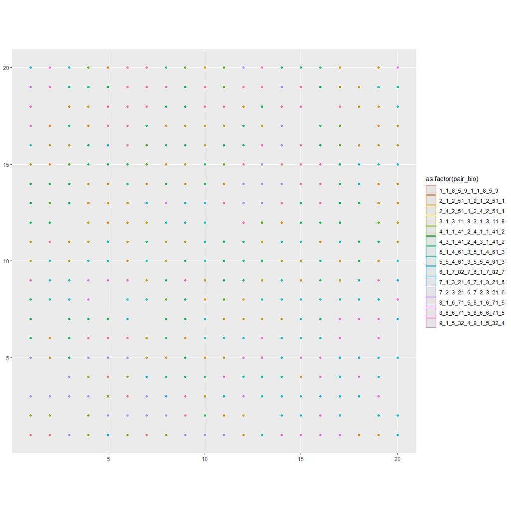

```r
# Plot with tiles
all100 %>%
  left_join(all_bioregions[, c("site", "x", "y")], by = c("id1" = "site")) %>%
  distinct(id1, .keep_all = TRUE) %>%
  st_as_sf(coords = c("x", "y")) %>%
  group_by(pair_bio) %>%
  st_cast("MULTIPOINT") %>%
  summarise() %>%
  ggplot() +
  geom_sf(aes(color = as.factor(pair_bio)))
```

```r
geom_tile(aes(fill = as.factor(pair_bio), color = as.factor(pair_bio)),
          alpha = 0.8, width = 1, height = 1)
```

```
## mapping: fill = ~as.factor(pair_bio), colour = ~as.factor(pair_bio)
## geom_tile: linejoin = mitre, na.rm = FALSE
## stat_identity: na.rm = FALSE
## position_identity
```

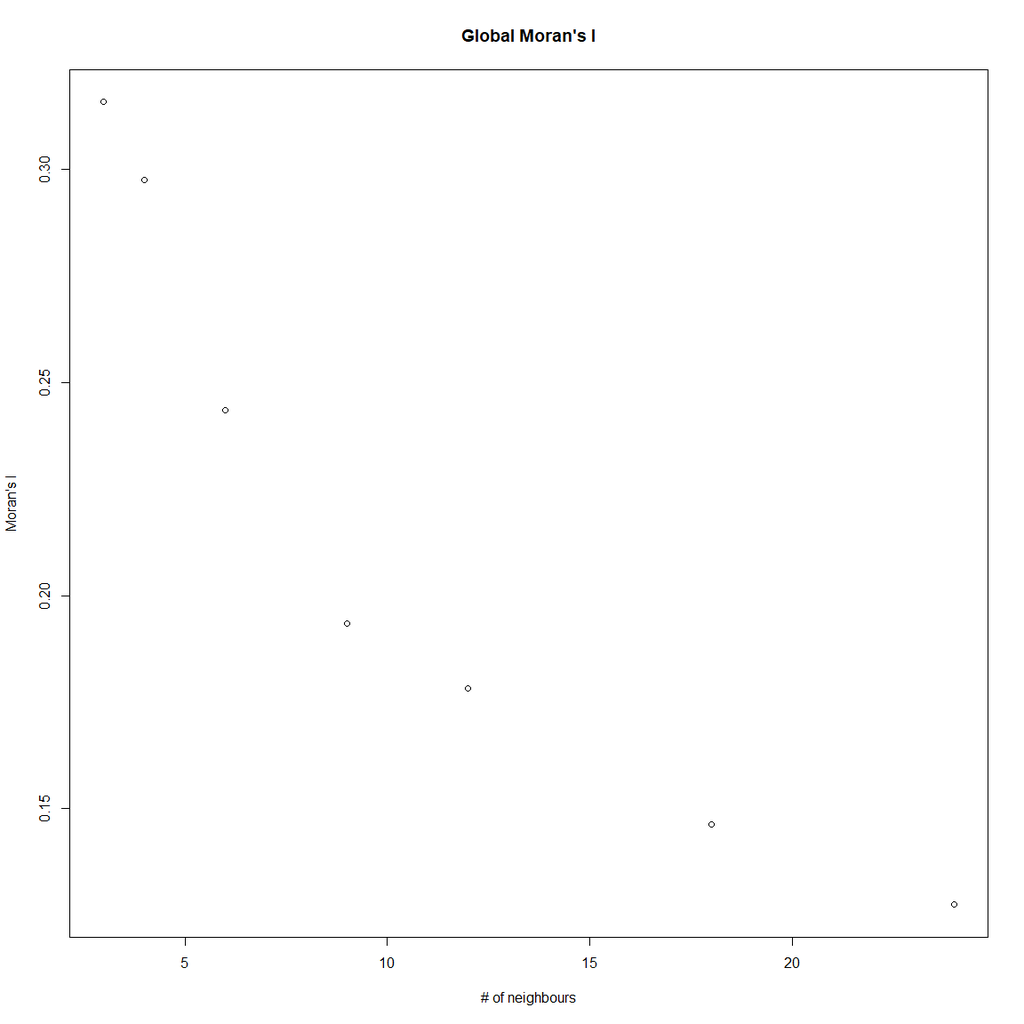

```r
## Autocorrelation
# https://mgimond.github.io/Spatial/spatial-autocorrelation-in-r.html
library(sp)
all_bioregions_sp <- all_bioregions
all_bioregions_sp <- all_bioregions_sp[complete.cases(all_bioregions_sp), ]
coordinates(all_bioregions_sp) <- ~x+y

all_bioregions_sp$oslom <- as.numeric(as.character(all_bioregions_sp$oslom))
all_bioregions_sp$ward <- as.numeric(as.character(all_bioregions_sp$ward))
all_bioregions_sp$greedy <- as.numeric(as.character(all_bioregions_sp$greedy))
all_bioregions_sp$lpawb <- as.numeric(as.character(all_bioregions_sp$lpawb))
all_bioregions_sp$infomap <- as.numeric(as.character(all_bioregions_sp$infomap))

coo <- coordinates(all_bioregions_sp)
# S.dist  <-  spdep::dnearneigh(coo, 0, 100)
# lw <- spdep::nb2listw(S.dist, style="W",zero.policy=T)
# MI  <-  spdep::moran.mc(all_bioregions_sp$oslom, lw, nsim=599,zero.policy=T)
# plot(MI, main = "", las = 1)

bws <- c(3, 4, 6, 9, 12, 18, 24)
moran_oslom <- lctools::moransI.v(coo, bws, all_bioregions_sp@data$oslom)
```

```r
moran_ward <- lctools::moransI.v(coo, bws, all_bioregions_sp@data$ward)
```

[figure not shown]

```r
moran_greedy <- lctools::moransI.v(coo, bws, all_bioregions_sp@data$greedy)
```

[figure not shown]

```r
moran_lpawb <- lctools::moransI.v(coo, bws, all_bioregions_sp@data$lpawb)
```

[figure not shown]

```r
moran_infomap <- lctools::moransI.v(coo, bws, all_bioregions_sp@data$infomap)
```

[figure not shown]

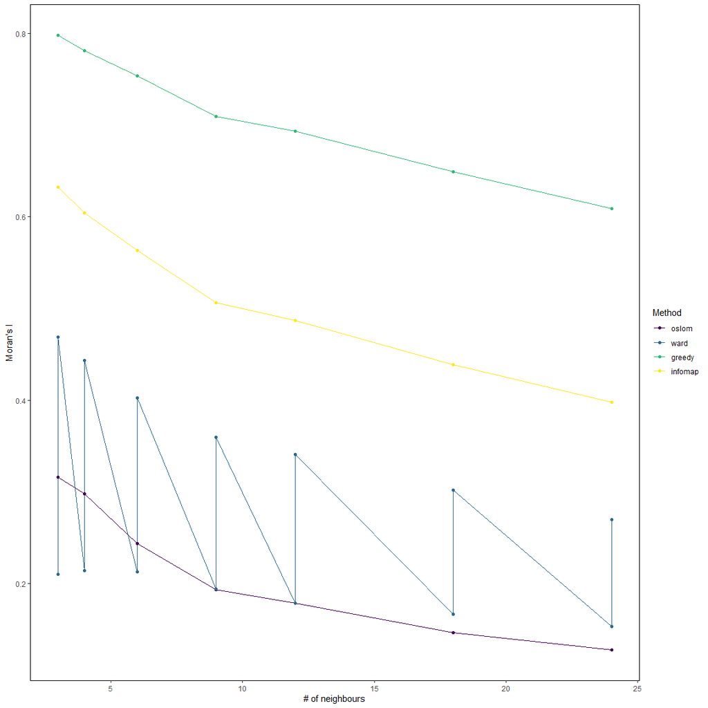

```r
all_moran <-
  rbind(data.frame(
    algo = "oslom", k = moran_oslom[, "k"],
    moran = moran_oslom[, "Moran's I"]),
    data.frame(algo = "ward", k = moran_ward[, "k"],
               moran = moran_ward[, "Moran's I"]),
    data.frame(algo = "ward", k = moran_ward[, "k"],
               moran = moran_greedy[, "Moran's I"]),
    data.frame(algo = "greedy", k = moran_greedy[, "k"],
               moran = moran_lpawb[, "Moran's I"]),
    data.frame(algo = "infomap", k = moran_infomap[, "k"],
               moran = moran_infomap[, "Moran's I"])
  )

ggplot(all_moran, aes(k, moran)) +
  geom_line(aes(color = as.factor(algo))) +
  geom_point(aes(color = as.factor(algo))) +
  scale_color_viridis_d("Method") +
  labs(x = "# of neighbours", y = "Moran's I") +
  theme_classic() +
  theme(panel.border = element_rect(fill= NA, color = "black"))
```

We can as well compare each pair of bioregion to each other.

```r
# sabre package: test between oslom and ward
# Spatial Association Between REgionalizations
library(sabre)
library(sf)

bioregions_sf <- st_as_sf(all_bioregions, coords = c("x", "y")) %>%
  st_cast(to = "MULTILINESTRING")

po <- vmeasure_calc(x = bioregions_sf, x_name = oslom,
                    y = bioregions_sf, y_name = ward)

# Groups of pixels through the different methods
list_group_oslom <- by(all_bioregions$site, all_bioregions$oslom, identity)
list_group_oslom <- lapply(list_group_oslom, as.character)

list_group_ward <- by(all_bioregions$site, all_bioregions$ward, identity)
list_group_ward <- lapply(list_group_ward, as.character)

list_group_greedy <- by(all_bioregions$site, all_bioregions$greedy, identity)
list_group_greedy<- lapply(list_group_greedy, as.character)

list_group_lpawb <- by(all_bioregions$site, all_bioregions$lpawb, identity)
list_group_lpawb <- lapply(list_group_lpawb, as.character)

list_group_infomap <- by(all_bioregions$site, all_bioregions$infomap, identity)
list_group_infomap <- lapply(list_group_infomap, as.character)

list_combined <- lapply(list_group_oslom, function(x) x[x %in% list_group_ward[[1]]])
list_combined <- lapply(list_combined, function(x) x[x %in% list_group_greedy[[1]]])
list_combined <- lapply(list_combined, function(x) x[x %in% list_group_lpawb[[1]]])
list_combined <- lapply(list_combined, function(x) x[x %in% list_group_infomap[[1]]])

# For one combination only
list1_oslom <-
  all_bioregions[which(all_bioregions$oslom == unique(all_bioregions$oslom)[1]),
                 "site"]
list1_ward <- all_bioregions[which(all_bioregions$ward == unique(all_bioregions$ward)[1]),
                             "site"]
list1_greedy <- all_bioregions[which(all_bioregions$greedy == unique(all_bioregions$greedy)[1]),
                               "site"]
list1_lpawb <- all_bioregions[which(all_bioregions$lpawb == unique(all_bioregions$lpawb)[1]),
                              "site"]
list1_infomap <- all_bioregions[which(all_bioregions$infomap == unique(all_bioregions$infomap)[1]),
                                "site"]

list1_combined <- list1_oslom[list1_oslom %in% list1_ward]
list1_combined <- list1_combined[list1_combined %in% list1_greedy]
list1_combined <- list1_combined[list1_combined %in% list1_lpawb]
list1_combined <- list1_combined[list1_combined %in% list1_infomap]

all_bioregions$combined <- NA
all_bioregions[which(all_bioregions$site %in% list1_combined), "combined"] <- "1"
```

# 8 Run all the steps together

All these functions can be called with the wrap-up `all_maps()` function.

```r
all_res <- all_maps(dat = sp_df, form = "tidy", site, sp, ab = NULL,
                    binary = TRUE,
                    similarity = "simpson", network_algo = "both",
                    saving_directory,
                    bipartite_algo = "greedy", weight = FALSE,
                    clustering = TRUE, ward_method = "ward.D2",
                    optim_method = "firstSEmax", nstart = 25, B = 50,
                    K.max = 20)
```